# Risk Factor Analysis

## Outcome Variable

**Outcome Variable:** ever_swasted

## Predictor Variables

**Intervention Variable:** impsan

**Adjustment Set:**

- arm
- sex
- W_mage
- meducyrs
- feducyrs
- hhwealth_quart
- hfoodsec
- W_mhtcm
- W_mwtkg
- W_mbmi
- W_nrooms
- W_nchldlt5
- W_parity
- impfloor
- safeh20
- delta_W_mage
- delta_meducyrs
- delta_feducyrs
- delta_hhwealth_quart
- delta_hfoodsec
- delta_W_mhtcm
- delta_W_mwtkg
- delta_W_mbmi
- delta_W_nrooms
- delta_W_nchldlt5
- delta_W_parity
- delta_impfloor
- delta_safeh20

## Stratifying Variables

The analysis was stratified on these variable(s):

- agecat
- studyid
- country

## Data Summary

| agecat | studyid | country | impsan | ever_swasted | n_cell | n |
| --- | --- | --- | --- | --- | --- | --- |
| 0-24 months (no birth wast) | COHORTS | GUATEMALA | 1 | 0 | 81 | 870 |
| 0-24 months (no birth wast) | COHORTS | GUATEMALA | 1 | 1 | 0 | 870 |
| 0-24 months (no birth wast) | COHORTS | GUATEMALA | 0 | 0 | 763 | 870 |
| 0-24 months (no birth wast) | COHORTS | GUATEMALA | 0 | 1 | 26 | 870 |
| 0-24 months (no birth wast) | COHORTS | INDIA | 1 | 0 | 1908 | 5168 |
| 0-24 months (no birth wast) | COHORTS | INDIA | 1 | 1 | 58 | 5168 |
| 0-24 months (no birth wast) | COHORTS | INDIA | 0 | 0 | 3009 | 5168 |
| 0-24 months (no birth wast) | COHORTS | INDIA | 0 | 1 | 193 | 5168 |
| 0-24 months (no birth wast) | COHORTS | PHILIPPINES | 1 | 0 | 169 | 1185 |
| 0-24 months (no birth wast) | COHORTS | PHILIPPINES | 1 | 1 | 10 | 1185 |
| 0-24 months (no birth wast) | COHORTS | PHILIPPINES | 0 | 0 | 917 | 1185 |
| 0-24 months (no birth wast) | COHORTS | PHILIPPINES | 0 | 1 | 89 | 1185 |
| 0-24 months (no birth wast) | CONTENT | PERU | 1 | 0 | 200 | 215 |
| 0-24 months (no birth wast) | CONTENT | PERU | 1 | 1 | 1 | 215 |
| 0-24 months (no birth wast) | CONTENT | PERU | 0 | 0 | 14 | 215 |
| 0-24 months (no birth wast) | CONTENT | PERU | 0 | 1 | 0 | 215 |
| 0-24 months (no birth wast) | JiVitA-3 | BANGLADESH | 1 | 0 | 17885 | 26502 |
| 0-24 months (no birth wast) | JiVitA-3 | BANGLADESH | 1 | 1 | 626 | 26502 |
| 0-24 months (no birth wast) | JiVitA-3 | BANGLADESH | 0 | 0 | 7670 | 26502 |
| 0-24 months (no birth wast) | JiVitA-3 | BANGLADESH | 0 | 1 | 321 | 26502 |
| 0-24 months (no birth wast) | JiVitA-4 | BANGLADESH | 1 | 0 | 3991 | 5381 |
| 0-24 months (no birth wast) | JiVitA-4 | BANGLADESH | 1 | 1 | 170 | 5381 |
| 0-24 months (no birth wast) | JiVitA-4 | BANGLADESH | 0 | 0 | 1159 | 5381 |
| 0-24 months (no birth wast) | JiVitA-4 | BANGLADESH | 0 | 1 | 61 | 5381 |
| 0-24 months (no birth wast) | LCNI-5 | MALAWI | 1 | 0 | 3 | 810 |
| 0-24 months (no birth wast) | LCNI-5 | MALAWI | 1 | 1 | 0 | 810 |
| 0-24 months (no birth wast) | LCNI-5 | MALAWI | 0 | 0 | 800 | 810 |
| 0-24 months (no birth wast) | LCNI-5 | MALAWI | 0 | 1 | 7 | 810 |
| 0-24 months (no birth wast) | MAL-ED | BANGLADESH | 1 | 0 | 193 | 242 |
| 0-24 months (no birth wast) | MAL-ED | BANGLADESH | 1 | 1 | 11 | 242 |
| 0-24 months (no birth wast) | MAL-ED | BANGLADESH | 0 | 0 | 37 | 242 |
| 0-24 months (no birth wast) | MAL-ED | BANGLADESH | 0 | 1 | 1 | 242 |
| 0-24 months (no birth wast) | MAL-ED | BRAZIL | 1 | 0 | 202 | 210 |
| 0-24 months (no birth wast) | MAL-ED | BRAZIL | 1 | 1 | 4 | 210 |
| 0-24 months (no birth wast) | MAL-ED | BRAZIL | 0 | 0 | 4 | 210 |
| 0-24 months (no birth wast) | MAL-ED | BRAZIL | 0 | 1 | 0 | 210 |
| 0-24 months (no birth wast) | MAL-ED | INDIA | 1 | 0 | 102 | 229 |
| 0-24 months (no birth wast) | MAL-ED | INDIA | 1 | 1 | 3 | 229 |
| 0-24 months (no birth wast) | MAL-ED | INDIA | 0 | 0 | 116 | 229 |
| 0-24 months (no birth wast) | MAL-ED | INDIA | 0 | 1 | 8 | 229 |
| 0-24 months (no birth wast) | MAL-ED | NEPAL | 1 | 0 | 232 | 236 |
| 0-24 months (no birth wast) | MAL-ED | NEPAL | 1 | 1 | 3 | 236 |
| 0-24 months (no birth wast) | MAL-ED | NEPAL | 0 | 0 | 1 | 236 |
| 0-24 months (no birth wast) | MAL-ED | NEPAL | 0 | 1 | 0 | 236 |
| 0-24 months (no birth wast) | MAL-ED | PERU | 1 | 0 | 65 | 263 |
| 0-24 months (no birth wast) | MAL-ED | PERU | 1 | 1 | 0 | 263 |
| 0-24 months (no birth wast) | MAL-ED | PERU | 0 | 0 | 194 | 263 |
| 0-24 months (no birth wast) | MAL-ED | PERU | 0 | 1 | 4 | 263 |
| 0-24 months (no birth wast) | MAL-ED | SOUTH AFRICA | 1 | 0 | 4 | 250 |
| 0-24 months (no birth wast) | MAL-ED | SOUTH AFRICA | 1 | 1 | 0 | 250 |
| 0-24 months (no birth wast) | MAL-ED | SOUTH AFRICA | 0 | 0 | 234 | 250 |
| 0-24 months (no birth wast) | MAL-ED | SOUTH AFRICA | 0 | 1 | 12 | 250 |
| 0-24 months (no birth wast) | MAL-ED | TANZANIA, UNITED REPUBLIC OF | 1 | 0 | 0 | 241 |
| 0-24 months (no birth wast) | MAL-ED | TANZANIA, UNITED REPUBLIC OF | 1 | 1 | 0 | 241 |
| 0-24 months (no birth wast) | MAL-ED | TANZANIA, UNITED REPUBLIC OF | 0 | 0 | 233 | 241 |
| 0-24 months (no birth wast) | MAL-ED | TANZANIA, UNITED REPUBLIC OF | 0 | 1 | 8 | 241 |
| 0-24 months (no birth wast) | NIH-Birth | BANGLADESH | 1 | 0 | 216 | 602 |
| 0-24 months (no birth wast) | NIH-Birth | BANGLADESH | 1 | 1 | 17 | 602 |
| 0-24 months (no birth wast) | NIH-Birth | BANGLADESH | 0 | 0 | 332 | 602 |
| 0-24 months (no birth wast) | NIH-Birth | BANGLADESH | 0 | 1 | 37 | 602 |
| 0-24 months (no birth wast) | NIH-Crypto | BANGLADESH | 1 | 0 | 634 | 743 |
| 0-24 months (no birth wast) | NIH-Crypto | BANGLADESH | 1 | 1 | 17 | 743 |
| 0-24 months (no birth wast) | NIH-Crypto | BANGLADESH | 0 | 0 | 89 | 743 |
| 0-24 months (no birth wast) | NIH-Crypto | BANGLADESH | 0 | 1 | 3 | 743 |
| 0-24 months (no birth wast) | PROVIDE | BANGLADESH | 1 | 0 | 50 | 52 |
| 0-24 months (no birth wast) | PROVIDE | BANGLADESH | 1 | 1 | 0 | 52 |
| 0-24 months (no birth wast) | PROVIDE | BANGLADESH | 0 | 0 | 2 | 52 |
| 0-24 months (no birth wast) | PROVIDE | BANGLADESH | 0 | 1 | 0 | 52 |

The following strata were considered:

- agecat: 0-24 months (no birth wast), studyid: COHORTS, country: GUATEMALA
- agecat: 0-24 months (no birth wast), studyid: COHORTS, country: INDIA
- agecat: 0-24 months (no birth wast), studyid: COHORTS, country: PHILIPPINES
- agecat: 0-24 months (no birth wast), studyid: CONTENT, country: PERU
- agecat: 0-24 months (no birth wast), studyid: JiVitA-3, country: BANGLADESH
- agecat: 0-24 months (no birth wast), studyid: JiVitA-4, country: BANGLADESH
- agecat: 0-24 months (no birth wast), studyid: LCNI-5, country: MALAWI
- agecat: 0-24 months (no birth wast), studyid: MAL-ED, country: BANGLADESH
- agecat: 0-24 months (no birth wast), studyid: MAL-ED, country: BRAZIL
- agecat: 0-24 months (no birth wast), studyid: MAL-ED, country: INDIA
- agecat: 0-24 months (no birth wast), studyid: MAL-ED, country: NEPAL
- agecat: 0-24 months (no birth wast), studyid: MAL-ED, country: PERU
- agecat: 0-24 months (no birth wast), studyid: MAL-ED, country: SOUTH AFRICA
- agecat: 0-24 months (no birth wast), studyid: MAL-ED, country: TANZANIA, UNITED REPUBLIC OF
- agecat: 0-24 months (no birth wast), studyid: NIH-Birth, country: BANGLADESH
- agecat: 0-24 months (no birth wast), studyid: NIH-Crypto, country: BANGLADESH
- agecat: 0-24 months (no birth wast), studyid: PROVIDE, country: BANGLADESH

### Dropped Strata

Some strata were dropped due to rare outcomes:

- agecat: 0-24 months (no birth wast), studyid: COHORTS, country: GUATEMALA
- agecat: 0-24 months (no birth wast), studyid: CONTENT, country: PERU
- agecat: 0-24 months (no birth wast), studyid: LCNI-5, country: MALAWI
- agecat: 0-24 months (no birth wast), studyid: MAL-ED, country: BANGLADESH
- agecat: 0-24 months (no birth wast), studyid: MAL-ED, country: BRAZIL
- agecat: 0-24 months (no birth wast), studyid: MAL-ED, country: INDIA
- agecat: 0-24 months (no birth wast), studyid: MAL-ED, country: NEPAL
- agecat: 0-24 months (no birth wast), studyid: MAL-ED, country: PERU
- agecat: 0-24 months (no birth wast), studyid: MAL-ED, country: SOUTH AFRICA
- agecat: 0-24 months (no birth wast), studyid: MAL-ED, country: TANZANIA, UNITED REPUBLIC OF
- agecat: 0-24 months (no birth wast), studyid: NIH-Crypto, country: BANGLADESH
- agecat: 0-24 months (no birth wast), studyid: PROVIDE, country: BANGLADESH

## Methods Detail

We're interested in the causal parameters $E[Y_a]$ for all values of $a \in \mathcal{A}$. These parameters represent the mean outcome if, possibly contrary to fact, we intervened to set all units to have $A=a$. Under the randomization and positivity assumptions, these are identified by the statistical parameters $\psi_a=E_W[E_{Y|A,W}(Y|A=a,W)]$. In addition, we're interested in the mean of $Y$, $E[Y]$ under no intervention (the observed mean). We will estimate these parameters by using SuperLearner to fit the relevant likelihood factors -- $E_{Y|A,W}(Y|A=a,W)$ and $p(A=a|W)$, and then updating our likelihood fit using a joint TMLE.

For unadjusted analyses ($W=\{\}$), initial likelihoods were estimated using Lrnr_glm to estimate the simple $E(Y|A)$ and Lrnr_mean to estimate $p(A)$. For adjusted analyses, a small library containing Lrnr_glmnet, Lrnr_xgboost, and Lrnr_mean was used.

Having estimated these parameters, we will then use the delta method to estimate relative risks and attributable risks relative to a prespecified baseline level of $A$.

# Results Detail

## Results Plots

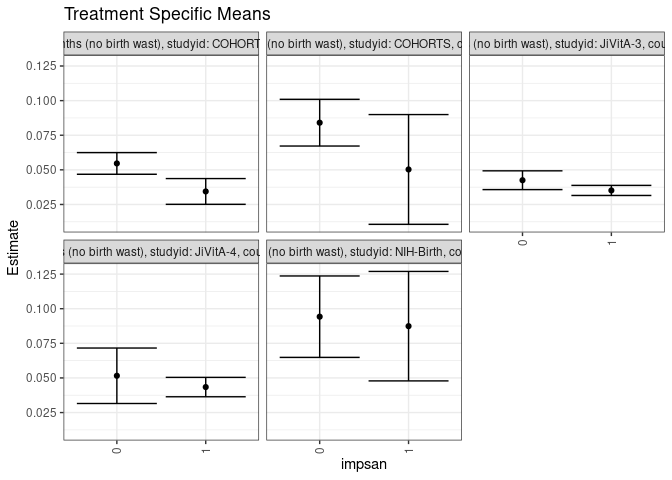

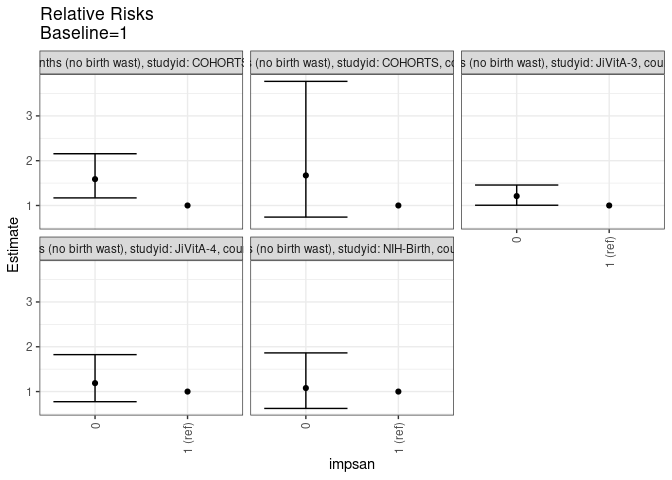

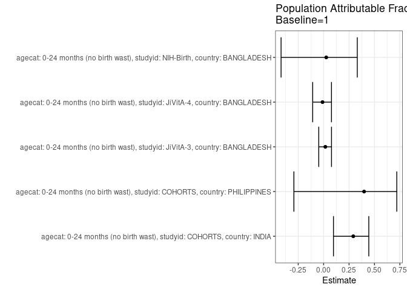

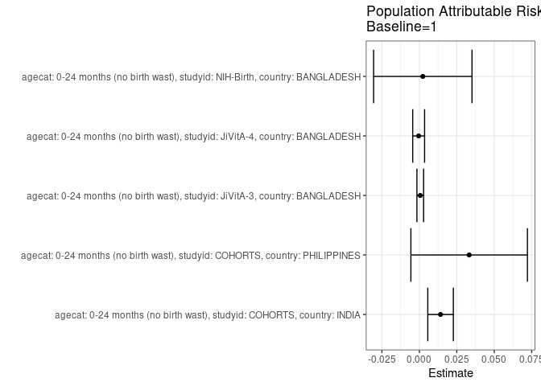

## Results Table

### Parameter: TSM

| agecat | studyid | country | intervention_level | baseline_level | estimate | ci_lower | ci_upper |
| --- | --- | --- | --- | --- | --- | --- | --- |
| 0-24 months (no birth wast) | COHORTS | INDIA | 1 | NA | 0.0344099 | 0.0251003 | 0.0437195 |
| 0-24 months (no birth wast) | COHORTS | INDIA | 0 | NA | 0.0546371 | 0.0468073 | 0.0624669 |
| 0-24 months (no birth wast) | COHORTS | PHILIPPINES | 1 | NA | 0.0502947 | 0.0106565 | 0.0899329 |
| 0-24 months (no birth wast) | COHORTS | PHILIPPINES | 0 | NA | 0.0840575 | 0.0671970 | 0.1009181 |
| 0-24 months (no birth wast) | JiVitA-3 | BANGLADESH | 1 | NA | 0.0351341 | 0.0314984 | 0.0387699 |
| 0-24 months (no birth wast) | JiVitA-3 | BANGLADESH | 0 | NA | 0.0425165 | 0.0357399 | 0.0492932 |
| 0-24 months (no birth wast) | JiVitA-4 | BANGLADESH | 1 | NA | 0.0434039 | 0.0364103 | 0.0503976 |
| 0-24 months (no birth wast) | JiVitA-4 | BANGLADESH | 0 | NA | 0.0515735 | 0.0315476 | 0.0715994 |
| 0-24 months (no birth wast) | NIH-Birth | BANGLADESH | 1 | NA | 0.0873911 | 0.0478708 | 0.1269114 |
| 0-24 months (no birth wast) | NIH-Birth | BANGLADESH | 0 | NA | 0.0942391 | 0.0648337 | 0.1236444 |

### Parameter: E(Y)

| agecat | studyid | country | intervention_level | baseline_level | estimate | ci_lower | ci_upper |
| --- | --- | --- | --- | --- | --- | --- | --- |
| 0-24 months (no birth wast) | COHORTS | INDIA | NA | NA | 0.0485681 | 0.0427068 | 0.0544294 |
| 0-24 months (no birth wast) | COHORTS | PHILIPPINES | NA | NA | 0.0835443 | 0.0677832 | 0.0993054 |
| 0-24 months (no birth wast) | JiVitA-3 | BANGLADESH | NA | NA | 0.0357332 | 0.0331536 | 0.0383127 |
| 0-24 months (no birth wast) | JiVitA-4 | BANGLADESH | NA | NA | 0.0429288 | 0.0372183 | 0.0486393 |
| 0-24 months (no birth wast) | NIH-Birth | BANGLADESH | NA | NA | 0.0897010 | 0.0668555 | 0.1125465 |

### Parameter: RR

| agecat | studyid | country | intervention_level | baseline_level | estimate | ci_lower | ci_upper |
| --- | --- | --- | --- | --- | --- | --- | --- |
| 0-24 months (no birth wast) | COHORTS | INDIA | 1 | 1 | 1.000000 | 1.0000000 | 1.000000 |
| 0-24 months (no birth wast) | COHORTS | INDIA | 0 | 1 | 1.587833 | 1.1696796 | 2.155473 |
| 0-24 months (no birth wast) | COHORTS | PHILIPPINES | 1 | 1 | 1.000000 | 1.0000000 | 1.000000 |
| 0-24 months (no birth wast) | COHORTS | PHILIPPINES | 0 | 1 | 1.671301 | 0.7407587 | 3.770793 |
| 0-24 months (no birth wast) | JiVitA-3 | BANGLADESH | 1 | 1 | 1.000000 | 1.0000000 | 1.000000 |
| 0-24 months (no birth wast) | JiVitA-3 | BANGLADESH | 0 | 1 | 1.210121 | 1.0055560 | 1.456301 |
| 0-24 months (no birth wast) | JiVitA-4 | BANGLADESH | 1 | 1 | 1.000000 | 1.0000000 | 1.000000 |
| 0-24 months (no birth wast) | JiVitA-4 | BANGLADESH | 0 | 1 | 1.188221 | 0.7739833 | 1.824159 |
| 0-24 months (no birth wast) | NIH-Birth | BANGLADESH | 1 | 1 | 1.000000 | 1.0000000 | 1.000000 |
| 0-24 months (no birth wast) | NIH-Birth | BANGLADESH | 0 | 1 | 1.078360 | 0.6240765 | 1.863331 |

### Parameter: PAR

| agecat | studyid | country | intervention_level | baseline_level | estimate | ci_lower | ci_upper |
| --- | --- | --- | --- | --- | --- | --- | --- |
| 0-24 months (no birth wast) | COHORTS | INDIA | 1 | NA | 0.0141582 | 0.0056252 | 0.0226913 |
| 0-24 months (no birth wast) | COHORTS | PHILIPPINES | 1 | NA | 0.0332496 | -0.0056615 | 0.0721608 |
| 0-24 months (no birth wast) | JiVitA-3 | BANGLADESH | 1 | NA | 0.0005990 | -0.0016342 | 0.0028323 |
| 0-24 months (no birth wast) | JiVitA-4 | BANGLADESH | 1 | NA | -0.0004751 | -0.0044390 | 0.0034887 |
| 0-24 months (no birth wast) | NIH-Birth | BANGLADESH | 1 | NA | 0.0023099 | -0.0305457 | 0.0351655 |

### Parameter: PAF

| agecat | studyid | country | intervention_level | baseline_level | estimate | ci_lower | ci_upper |
| --- | --- | --- | --- | --- | --- | --- | --- |
| 0-24 months (no birth wast) | COHORTS | INDIA | 1 | NA | 0.2915131 | 0.0968818 | 0.4441993 |
| 0-24 months (no birth wast) | COHORTS | PHILIPPINES | 1 | NA | 0.3979881 | -0.2926945 | 0.7196412 |
| 0-24 months (no birth wast) | JiVitA-3 | BANGLADESH | 1 | NA | 0.0167637 | -0.0479524 | 0.0774833 |
| 0-24 months (no birth wast) | JiVitA-4 | BANGLADESH | 1 | NA | -0.0110677 | -0.1077422 | 0.0771699 |
| 0-24 months (no birth wast) | NIH-Birth | BANGLADESH | 1 | NA | 0.0257513 | -0.4187202 | 0.3309740 |